# Peanut vs Almond Butter: Nutritional Analysis

DSST389: Advanced Data Science

Author

Affiliation

*Anush Margaryan & Cooper Woods*

University of Richmond

Published

February 17, 2025

## Introduction

Approximately **4.5 million U.S. adults** have peanut allergies, making it one of the most prevalent food allergies. You can read more about peanut allergy prevalence and characteristics [here](https://www.jacionline.org/article/S0091-6749%2820%2932412-X/fulltext). Thus, it is important to find **nutritionally comparable alternatives**.

For our project, we investigate whether almond butter, a popular alternative, can provide **similar protein content** to peanut butter. Additionally, we compare the **degree of processing (FPro)** characterizing peanut and almond butter preparation techniques. **It is important to note that a lower FPro score indicates that the food is less processed.**

We obtained our data from [True Food](https://www.truefood.tech), powered by a comprehensive database Grocery DB, for peanut and almond butter **protein content** and **FPro score** across the available brands.

### Library Setup

Below we will import the necessary libraries for our analysis.

```r
library(tidyverse) #Data manipulation, visualization, and analysis
library(ggrepel) #Improved readability of labels
library(dplyr) #Efficient data manipulation
library(stringr) #Character string manipulation
library(rstatix) #Used for calculating error bars
theme_set(theme_minimal()) #Minimalistic theme for the plots
```

## About the data

We begin by loading the dataset. Here are the first few rows of `butters`:

[output not shown]

```
# A tibble: 6 × 5
  name                               fpro_score protein category      ...5
  <chr>                                   <dbl>   <dbl> <chr>         <lgl>
1 Teddie All Natural Smooth Unsalted      0.116    25   peanut butter NA
2 Justin's Classic                        0.447    21.9 peanut butter NA
3 Nuts'n More                             0.501    33.3 peanut butter NA
4 Teddie All Natural Super Chunky         0.495    25   peanut butter NA
5 Teddie All Natural Smooth               0.495    25   peanut butter NA
6 365 Whole Foods Crunchy                 0.630    25   peanut butter NA
```

### Description

- The `butters` data was extracted from the **True Food** database.
- It contains **32 rows**, each representing 11 peanut and 21 almond butter brands.

### Data dictionary

Columns we will analyze include:

| Column Name | Description | Unit |
| --- | --- | --- |
| `name` | Product name as marketed | Character (text) |
| `fpro_score` | Food processing score | Scaled 0 to 1 |
| `protein` | Protein content per serving | Grams (g) |
| `category` | Type of butter | “Peanut” or “Almond” |

## Data Analysis and Visualizations

### Scatterplot of FPro Score vs. Protein Conent (g)

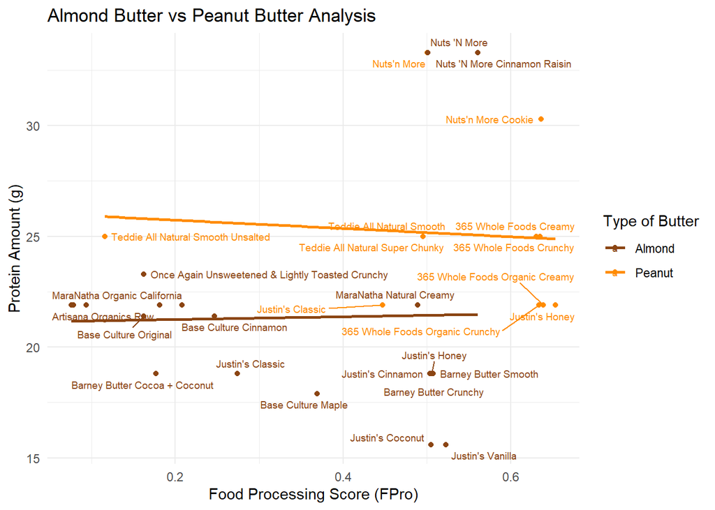

Figure 1. Scatterplot showing the relationship between food processing score (FPro) and protein content per serving (g) for various peanut (in orange) and almond (in brown) butters.

### Bar Chart Comparing Average FPro Scores for Almond and Peanut Butters

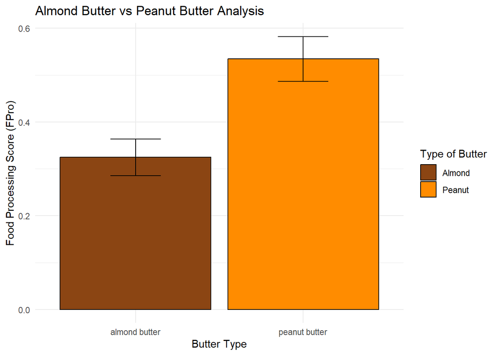

## Conclusions

Overall, our analysis suggests that there is no clear correlation between processing and protein content. While **peanut butter** has naturally **higher protein content**, **almond butter** seems to be generally **less processed**. Thus, individuals with peanut allergies should look for a balance bwteen lower processing and higher protein content in almond butters.